# Transformer

## 7.4. Analysis of Results

- Visualize a single prediction
  - Given 25 timesteps, predict 1

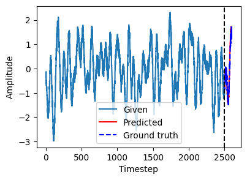

```python
horizon  = 2500
val_seg  = signal[-(n_step * n_input + horizon):]

window_flat = val_seg[: n_step * n_input]
gt_future   = val_seg[n_step * n_input:]

window = (torch.from_numpy(window_flat.astype(np.float32))
              .view(1, n_step, n_input)
              .to(device))

model.eval()
with torch.no_grad():
    one_pred = model(window).cpu().numpy().ravel()

plt.figure(figsize=(4.3, 3))
plt.plot(range(n_step * n_input), window_flat, label="Given")
plt.plot(range(n_step * n_input, n_step * n_input + n_input),
         one_pred, 'r', label="Predicted")
plt.plot(range(n_step * n_input, n_step * n_input + n_input),
         gt_future[:n_input], 'b--', label="Ground truth")
plt.axvline(n_step * n_input, color='k', linestyle='--')
plt.xlabel("Timestep"); plt.ylabel("Amplitude"); plt.legend()
plt.show()
```

- Roll-out the predictions 25 times
  - Autoregressive prediction (forecasting)

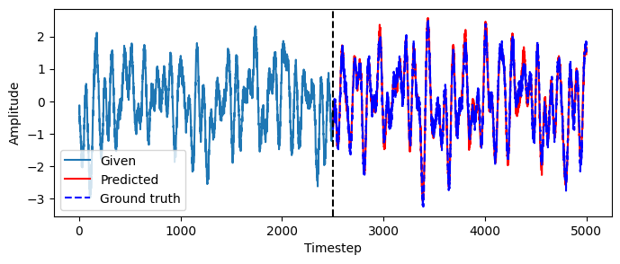

```python
preds = []
roll_window = window.clone()

with torch.no_grad():
    for _ in range(horizon // n_input):
        out = model(roll_window)
        preds.append(out.cpu().numpy().ravel())
        roll_window = torch.cat([roll_window[:, 1:], out.unsqueeze(1)], dim=1)

preds = np.concatenate(preds)

plt.figure(figsize=(8, 3))
plt.plot(range(n_step * n_input), window_flat, label="Given")
plt.plot(range(n_step * n_input, n_step * n_input + horizon),
         preds, 'r', label="Predicted")
plt.plot(range(n_step * n_input, n_step * n_input + horizon),
         gt_future, 'b--', label="Ground truth")
plt.axvline(n_step * n_input, color='k', linestyle='--')
plt.xlabel("Timestep"); plt.ylabel("Amplitude"); plt.legend()
plt.show()
```

# 8. Solving Engineering Problems with Transformers (1)

Making a Surrogate Model

- Sequence-to-sequence mapping: From load profiles to stress profiles

## 8.1. Loading the dataset and defining the dataloader

**Download data**

Load profiles [here](https://drive.google.com/file/d/18bBt4cAhJ3h6PUK2mwCmbzpqeEhRhtUb/view?usp=sharing)

Stress profiles [here](https://drive.google.com/file/d/1InI9keWnP4Uho5TpbPw8UXwIIP0TVrXQ/view?usp=sharing)

```python
import numpy as np
import math
import matplotlib.pyplot as plt
import torch
import torch.nn as nn
import torch.nn.functional as F
from torch.utils.data import Dataset, DataLoader, random_split
import random

random.seed(42)
```

```python
from google.colab import drive
drive.mount('/content/drive')
```

```python
loads   = np.load('/content/drive/MyDrive/DL/DL_data/TransformerData/loads.npy')      # shape (N, T_load)
stresses = np.load('/content/drive/MyDrive/DL/DL_data/TransformerData/stresses.npy')  # shape (N, T_stress)
print(f"Loaded loads:   {loads.shape}")
print(f"Loaded stresses:{stresses.shape}")
```

```
Loaded loads:   (10000, 200)
Loaded stresses:(10000, 200)
```

```python
loads    = (loads    - loads.mean())    / loads.std()
stresses = (stresses - stresses.mean()) / stresses.std()

class CantileverDataset(Dataset):
    def __init__(self, X, y):
        self.X = torch.from_numpy(X).float()
        self.y = torch.from_numpy(y).float()
    def __len__(self):
        return len(self.X)
    def __getitem__(self, idx):
        return self.X[idx], self.y[idx]

ds = CantileverDataset(loads, stresses)
n_train = int(0.8 * len(ds))
train_ds, test_ds = random_split(ds, [n_train, len(ds) - n_train])

train_loader = DataLoader(train_ds, batch_size=64, shuffle=True)
test_loader  = DataLoader(test_ds,  batch_size=64, shuffle=False)

print(f"Train samples: {len(train_ds)}, Test samples: {len(test_ds)}")
```

```
Train samples: 8000, Test samples: 2000
```

- Visualize a single pair

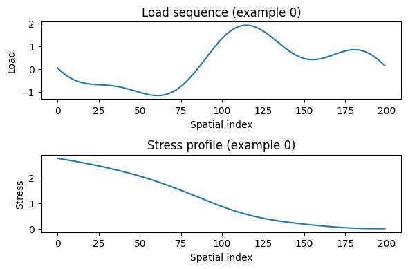

```python
x0, y0 = ds[0]
plt.figure(figsize=(6,4))
plt.subplot(2,1,1)
plt.plot(x0.numpy())
plt.title("Load sequence (example 0)")
plt.xlabel("Spatial index"); plt.ylabel("Load")

plt.subplot(2,1,2)
plt.plot(y0.numpy())
plt.title("Stress profile (example 0)")
plt.xlabel("Spatial index"); plt.ylabel("Stress")
plt.tight_layout()
plt.show()
```

## 8.2. Define Transformer

- Using **PyTorch's modules** simplifies the model definition

```python
class TransformerEncoderRegressor(nn.Module):
    def __init__(self, seq_len, d_model=64, nhead=8, num_layers=3, dim_feedforward=256, dropout=0.1):
        super().__init__()
        self.input_proj = nn.Linear(1, d_model)
        pe = torch.zeros(seq_len, d_model)
        pos = torch.arange(seq_len).unsqueeze(1).float()
        div = torch.exp(torch.arange(0, d_model, 2).float() * -(math.log(10000.0) / d_model))
        pe[:, 0::2] = torch.sin(pos * div)
        pe[:, 1::2] = torch.cos(pos * div)
        self.register_buffer("pos_encoding", pe.unsqueeze(0))

        encoder_layer = nn.TransformerEncoderLayer(
            d_model=d_model,
            nhead=nhead,
            dim_feedforward=dim_feedforward,
            dropout=dropout,
            batch_first=True
        )
        self.encoder = nn.TransformerEncoder(encoder_layer, num_layers=num_layers)

        self.output_head = nn.Linear(d_model, 1)

    def forward(self, x):
        h = self.input_proj(x)
        h = h + self.pos_encoding
        h = self.encoder(h)
        return self.output_head(h)
```

## 8.3. Training

```python
device = torch.device("cuda" if torch.cuda.is_available() else "cpu")
model = TransformerEncoderRegressor(loads.shape[1]).to(device)
criterion = nn.MSELoss()
optimizer = torch.optim.Adam(model.parameters(), lr=5e-4)

epochs = 10

for epoch in range(1, epochs + 1):
    model.train()
    train_loss = 0.0
    for src, tgt in train_loader:
        src = src.unsqueeze(-1).to(device)
        tgt = tgt.unsqueeze(-1).to(device)

        pred = model(src)
        loss = criterion(pred, tgt)

        optimizer.zero_grad()
        loss.backward()
        optimizer.step()

        train_loss += loss.item()

    train_loss /= len(train_loader)

    model.eval()
    test_loss = 0.0
    with torch.no_grad():
        for src, tgt in test_loader:

            src = src.unsqueeze(-1).to(device)
            tgt = tgt.unsqueeze(-1).to(device)

            pred = model(src)
            loss = criterion(pred, tgt)
            test_loss += loss.item()

    test_loss /= len(test_loader)

    print(f"Epoch {epoch}/{epochs} | Train MSE: {train_loss:.6f}")
```

[output not shown]

## 8.4. Analysis of Results

- Visualize GT stress profile vs. predicted stress profiles for a few samples

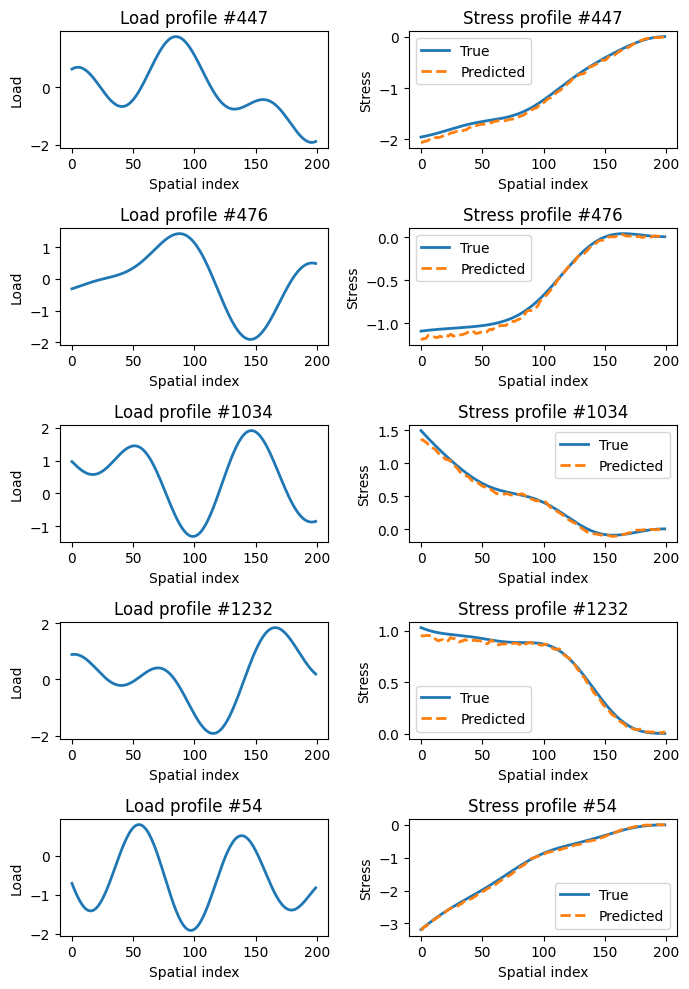

```python
model.eval()

all_preds = []
with torch.no_grad():
    for src, _ in test_loader:
        src = src.unsqueeze(-1).to(device)
        out = model(src).cpu().squeeze(-1)
        all_preds.append(out)
preds = torch.cat(all_preds, dim=0)

n_examples = 5
indices    = random.sample(range(len(test_ds)), n_examples)

fig, axes = plt.subplots(n_examples, 2, figsize=(7, 2*n_examples))
for i, idx in enumerate(indices):
    load, true = test_ds[idx]
    pred       = preds[idx]

    ax = axes[i, 0]
    ax.plot(load.numpy(), linewidth=2)
    ax.set_title(f"Load profile #{idx}")
    ax.set_xlabel("Spatial index")
    ax.set_ylabel("Load")

    ax = axes[i, 1]
    ax.plot(true.numpy(), label="True", linewidth=2)
    ax.plot(pred.numpy(), "--", label="Predicted", linewidth=2)
    ax.set_title(f"Stress profile #{idx}")
    ax.set_xlabel("Spatial index")
    ax.set_ylabel("Stress")
    ax.legend()

plt.tight_layout()
plt.show()
```

# 9. Solving Engineering Problems with Transformers (2)

## 9.1. Temporal Flow Field Prediction

**Sequence prediction with flow field snapshots**

**Download data**

Flow field snapshots [here](https://drive.google.com/file/d/1M3KiuCj3SDYkpmf6dEjr-erTWQzhIYXl/view?usp=sharing)

```python
import numpy as np
import math
import matplotlib.pyplot as plt
import torch
import torch.nn as nn
import torch.nn.functional as F
from torch.utils.data import Dataset, DataLoader, random_split
import random

random.seed(42)

u = np.load('/content/drive/MyDrive/DL/DL_data/TransformerData/u_field.npy')
print(f"Loaded u_field: {u.shape}")

window_size = 5
validation_frames = 5
n_batch = 16
nx, ny, _ = u.shape

n_snap = u.shape[2]
flat = u.transpose(2, 0, 1).reshape(n_snap, -1)

train_flat = flat[:-validation_frames]
val_flat   = flat[-(validation_frames + window_size):]

class FlowfieldDataset(Dataset):
    def __init__(self, arr, ctx):
        xs, ys = [], []
        for i in range(len(arr) - ctx):
            xs.append(arr[i:i+ctx])
            ys.append(arr[i+ctx])
        self.x = torch.from_numpy(np.stack(xs)).float()
        self.y = torch.from_numpy(np.stack(ys)).float()
    def __len__(self):
        return len(self.x)
    def __getitem__(self, idx):
        return self.x[idx], self.y[idx]

train_ds = FlowfieldDataset(train_flat, window_size)
val_ds   = FlowfieldDataset(val_flat,   window_size)

train_loader = DataLoader(train_ds, batch_size=n_batch, shuffle=True)
val_loader   = DataLoader(val_ds,   batch_size=n_batch, shuffle=False)

print(f"Train samples: {len(train_ds)}, Val samples: {len(val_ds)}")
```

```
Loaded u_field: (199, 449, 151)
Train samples: 141, Val samples: 5
```

```python
class TransformerDecoder(nn.Module):
    def __init__(
        self,
        ctx,
        feat_dim,
        d_model=512,
        nhead=8,
        num_layers=4,
        dim_feedforward=2048,
        dropout=0.1
    ):
        super().__init__()
        self.in_proj = nn.Linear(feat_dim, d_model)

        pe = torch.zeros(ctx, d_model)
        pos = torch.arange(ctx).unsqueeze(1).float()
        div = torch.exp(
            torch.arange(0, d_model, 2).float() * -(math.log(10000.0) / d_model)
        )
        pe[:, 0::2] = torch.sin(pos * div)
        pe[:, 1::2] = torch.cos(pos * div)
        self.pos_encoding = pe.unsqueeze(0)

        mask = torch.triu(torch.ones(ctx, ctx), diagonal=1).bool()
        self.causal_mask = mask

        layer = nn.TransformerEncoderLayer(
            d_model=d_model,
            nhead=nhead,
            dim_feedforward=dim_feedforward,
            dropout=dropout,
            batch_first=True
        )
        self.encoder = nn.TransformerEncoder(layer, num_layers=num_layers)

        self.out_proj = nn.Linear(d_model, feat_dim)

    def forward(self, x):
        pos = self.pos_encoding.to(x.device)
        mask = self.causal_mask.to(x.device)

        h = self.in_proj(x) + pos
        h = self.encoder(h, mask)
        return self.out_proj(h[:, -1])
```

```python
device = torch.device("cuda" if torch.cuda.is_available() else "cpu")

feat_dim = train_flat.shape[1]
model = TransformerDecoder(window_size, feat_dim).to(device)
criterion = nn.MSELoss()
optimizer = torch.optim.Adam(model.parameters(), lr=5e-4)
epochs = 200

for epoch in range(1, epochs + 1):
    model.train()
    train_loss = 0.0

    for src, tgt in train_loader:
        src, tgt = src.to(device), tgt.to(device)
        pred = model(src)
        loss = criterion(pred, tgt)
        optimizer.zero_grad()
        loss.backward()
        optimizer.step()
        train_loss += loss.item()

    train_loss /= len(train_loader)

    print(f"Epoch {epoch}/{epochs} | Train MSE: {train_loss:.6f}")
```

You can skip training by downloading pretrained model [here](https://drive.google.com/file/d/1wN-ia5wotF_Y5ImeSWM_eSnlzzSxQd5I/view?usp=sharing)

```python
device = torch.device("cuda" if torch.cuda.is_available() else "cpu")
feat_dim = train_flat.shape[1]
model = TransformerDecoder(window_size, feat_dim).to(device)

load_path = '/content/drive/MyDrive/DL/DL_data/TransformerData/u_forecast_weights.pth'
state     = torch.load(load_path, map_location=device)
model.load_state_dict(state)
model.eval()

print(f"Loaded TransformerDecoder weights from {load_path}")
```

```
Loaded TransformerDecoder weights from /content/drive/MyDrive/DL/DL_data/TransformerData/u_forecast_weights.pth
```

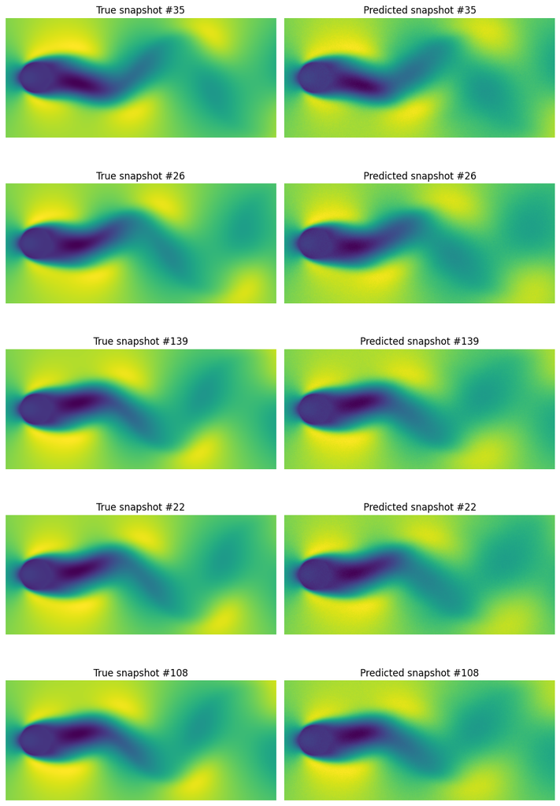

```python
model.eval()

preds = []
with torch.no_grad():
    for seq, _ in train_ds:
        inp = seq.unsqueeze(0).to(device)
        out = model(inp).cpu().squeeze(0)
        preds.append(out.numpy())

n_examples = 5
indices = random.sample(range(len(train_ds)), n_examples)

fig, axes = plt.subplots(n_examples, 2, figsize=(10, 3*n_examples))
for i, idx in enumerate(indices):
    _, true_frame = train_ds[idx]
    pred_frame    = preds[idx]

    true_img = true_frame.numpy().reshape(nx, ny)
    pred_img = pred_frame.reshape(nx, ny)

    ax = axes[i, 0]
    ax.imshow(true_img, origin="lower")
    ax.set_title(f"True snapshot #{idx}")
    ax.axis("off")

    ax = axes[i, 1]
    ax.imshow(pred_img, origin="lower")
    ax.set_title(f"Predicted snapshot #{idx}")
    ax.axis("off")

plt.tight_layout()
plt.show()
```

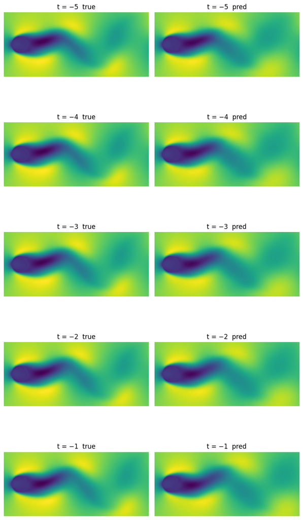

```python
model.eval()

last_window = flat[-(validation_frames + window_size):-validation_frames]
future_true = flat[-validation_frames:]

input_tensor = torch.from_numpy(last_window).float().unsqueeze(0).to(device)
predictions = []

with torch.no_grad():
    for _ in range(validation_frames):
        out = model(input_tensor)
        frame_pred = out[0]
        predictions.append(frame_pred.cpu().numpy())
        input_tensor = torch.cat([
            input_tensor[:, 1:, :],
            frame_pred.unsqueeze(0).unsqueeze(0).to(device)
        ], dim=1)

pred_np = np.stack(predictions)
gt = future_true.reshape(validation_frames, nx, ny)
pr = pred_np.reshape(validation_frames, nx, ny)
err = pr - gt

fig, axes = plt.subplots(validation_frames, 2, figsize=(8, 3*validation_frames))
for t in range(validation_frames):
    ax = axes[t, 0]
    ax.imshow(gt[t], origin='lower')
    ax.set_title(f"t = −{validation_frames-t}  true")
    ax.axis("off")

    ax = axes[t, 1]
    ax.imshow(pr[t], origin='lower')
    ax.set_title(f"t = −{validation_frames-t}  pred")
    ax.axis("off")

plt.tight_layout()
plt.show()
```

```python
%%javascript
$.getScript('https://kmahelona.github.io/ipython_notebook_goodies/ipython_notebook_toc.js')
```